# week_09_review_pca

## CMPINF 2100 Week 09

### Review PCA with the Sonar dataset

## Import Modules

```python
import numpy as np
import pandas as pd
import matplotlib.pyplot as plt

import seaborn as sns
```

Also import functions from sklearn.

```python
from sklearn.preprocessing import StandardScaler
```

```python
from sklearn.decomposition import PCA
```

## Read data

```python
sonar_url = 'https://archive.ics.uci.edu/ml/machine-learning-databases/undocumented/connectionist-bench/sonar/sonar.all-data'
```

```python
sonar_df = pd.read_csv( sonar_url, header=None )
```

```python
sonar_df.shape
```

```
(208, 61)
```

```python
sonar_df
```

|  | 0 | 1 | 2 | 3 | 4 | 5 | 6 | 7 | 8 | 9 | ... | 51 | 52 | 53 | 54 | 55 | 56 | 57 | 58 | 59 | 60 |
| --- | --- | --- | --- | --- | --- | --- | --- | --- | --- | --- | --- | --- | --- | --- | --- | --- | --- | --- | --- | --- | --- |
| 0 | 0.0200 | 0.0371 | 0.0428 | 0.0207 | 0.0954 | 0.0986 | 0.1539 | 0.1601 | 0.3109 | 0.2111 | ... | 0.0027 | 0.0065 | 0.0159 | 0.0072 | 0.0167 | 0.0180 | 0.0084 | 0.0090 | 0.0032 | R |
| 1 | 0.0453 | 0.0523 | 0.0843 | 0.0689 | 0.1183 | 0.2583 | 0.2156 | 0.3481 | 0.3337 | 0.2872 | ... | 0.0084 | 0.0089 | 0.0048 | 0.0094 | 0.0191 | 0.0140 | 0.0049 | 0.0052 | 0.0044 | R |
| 2 | 0.0262 | 0.0582 | 0.1099 | 0.1083 | 0.0974 | 0.2280 | 0.2431 | 0.3771 | 0.5598 | 0.6194 | ... | 0.0232 | 0.0166 | 0.0095 | 0.0180 | 0.0244 | 0.0316 | 0.0164 | 0.0095 | 0.0078 | R |
| 3 | 0.0100 | 0.0171 | 0.0623 | 0.0205 | 0.0205 | 0.0368 | 0.1098 | 0.1276 | 0.0598 | 0.1264 | ... | 0.0121 | 0.0036 | 0.0150 | 0.0085 | 0.0073 | 0.0050 | 0.0044 | 0.0040 | 0.0117 | R |
| 4 | 0.0762 | 0.0666 | 0.0481 | 0.0394 | 0.0590 | 0.0649 | 0.1209 | 0.2467 | 0.3564 | 0.4459 | ... | 0.0031 | 0.0054 | 0.0105 | 0.0110 | 0.0015 | 0.0072 | 0.0048 | 0.0107 | 0.0094 | R |
| ... | ... | ... | ... | ... | ... | ... | ... | ... | ... | ... | ... | ... | ... | ... | ... | ... | ... | ... | ... | ... | ... |
| 203 | 0.0187 | 0.0346 | 0.0168 | 0.0177 | 0.0393 | 0.1630 | 0.2028 | 0.1694 | 0.2328 | 0.2684 | ... | 0.0116 | 0.0098 | 0.0199 | 0.0033 | 0.0101 | 0.0065 | 0.0115 | 0.0193 | 0.0157 | M |
| 204 | 0.0323 | 0.0101 | 0.0298 | 0.0564 | 0.0760 | 0.0958 | 0.0990 | 0.1018 | 0.1030 | 0.2154 | ... | 0.0061 | 0.0093 | 0.0135 | 0.0063 | 0.0063 | 0.0034 | 0.0032 | 0.0062 | 0.0067 | M |
| 205 | 0.0522 | 0.0437 | 0.0180 | 0.0292 | 0.0351 | 0.1171 | 0.1257 | 0.1178 | 0.1258 | 0.2529 | ... | 0.0160 | 0.0029 | 0.0051 | 0.0062 | 0.0089 | 0.0140 | 0.0138 | 0.0077 | 0.0031 | M |
| 206 | 0.0303 | 0.0353 | 0.0490 | 0.0608 | 0.0167 | 0.1354 | 0.1465 | 0.1123 | 0.1945 | 0.2354 | ... | 0.0086 | 0.0046 | 0.0126 | 0.0036 | 0.0035 | 0.0034 | 0.0079 | 0.0036 | 0.0048 | M |
| 207 | 0.0260 | 0.0363 | 0.0136 | 0.0272 | 0.0214 | 0.0338 | 0.0655 | 0.1400 | 0.1843 | 0.2354 | ... | 0.0146 | 0.0129 | 0.0047 | 0.0039 | 0.0061 | 0.0040 | 0.0036 | 0.0061 | 0.0115 | M |

208 rows × 61 columns

Lets rename the COLS to show the following patterns!!

```python
sonar_df.columns = ["X%02d" % d for d in sonar_df.columns]
```

```python
sonar_df.dtypes.value_counts()
```

```
float64    60
object      1
Name: count, dtype: int64
```

```python
sonar_df.select_dtypes("object").info()
```

```
<class 'pandas.core.frame.DataFrame'>
RangeIndex: 208 entries, 0 to 207
Data columns (total 1 columns):
 #   Column  Non-Null Count  Dtype
---  ------  --------------  -----
 0   X60     208 non-null    object
dtypes: object(1)
memory usage: 1.8+ KB
```

Numeric cols are HIGHLY correlated!!

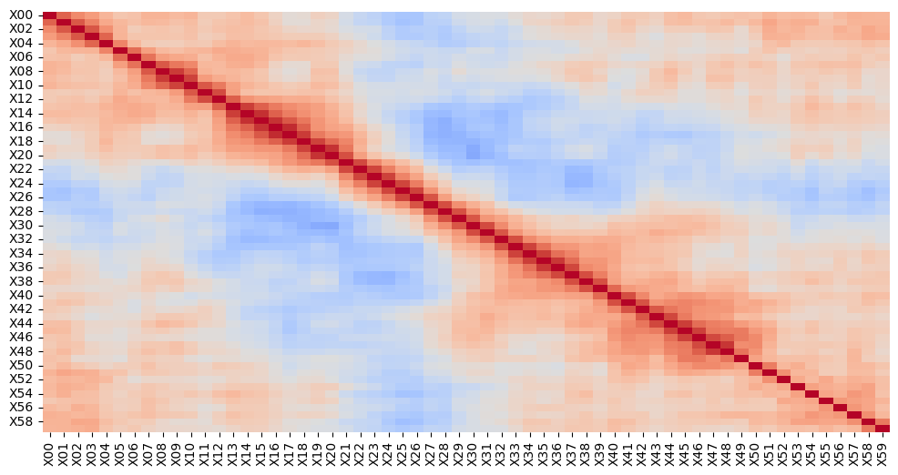

```python
fig, ax = plt.subplots(figsize=(12, 6))

sns.heatmap(data=sonar_df.corr(numeric_only=True),
            vmax=1,
            vmin=-1,
            center=0,
            cbar=False,
            cmap="coolwarm",
            ax=ax)

plt.show()
```

PCA exploits correlation!!

PCA crafts or creates new variables based on correlated numeric columns!

## Extract or Select the numeric columns

```python
sonar_features = sonar_df.select_dtypes("number").copy()
```

## Standardize the numeric features

```python
Xsonar = StandardScaler().fit_transform(sonar_features)
```

```python
Xsonar.shape
```

```
(208, 60)
```

## PCA

But we will NOT use the same approach that we have used up to this point.

We will **NOT** specify the n_components argument to PCA().

Lets see what happens if we use DEFAULT arguments to PCA...meaning we will NOT specify arguments when PCA object is initialized!!

```python
sonar_pca = PCA().fit_transform(Xsonar)
```

Check the shape

```python
sonar_pca.shape
```

```
(208, 60)
```

There are as many cols returned as the num of cols in the data!!

We have previously specified n_components just to support simple visualization.

But PCA is capable of giving you MORE than just 2 new variables.

PCA creates as many NEW variables as there are in the original data!!!

```python
type(sonar_pca)
```

```
numpy.ndarray
```

Convert the sonar_pca to a DataFrame using the naming pattern:

pca01, pca02, pcaN, ...

Create the DataFrame containing ALL PCs!!

```python
sonar_pca_df = pd.DataFrame(sonar_pca, columns=['pc%02d' % d for d in range(1, sonar_pca.shape[1]+1)])
```

```python
sonar_pca_df
```

|  | pc01 | pc02 | pc03 | pc04 | pc05 | pc06 | pc07 | pc08 | pc09 | pc10 | ... | pc51 | pc52 | pc53 | pc54 | pc55 | pc56 | pc57 | pc58 | pc59 | pc60 |
| --- | --- | --- | --- | --- | --- | --- | --- | --- | --- | --- | --- | --- | --- | --- | --- | --- | --- | --- | --- | --- | --- |
| 0 | 1.921168 | -1.370893 | -1.666476 | 0.837913 | -1.057324 | 1.712504 | 1.785716 | -1.581264 | 0.335418 | -1.028065 | ... | -0.335958 | -0.331626 | -0.198251 | -0.216336 | 0.097644 | -0.136728 | -0.004505 | -0.095476 | 0.037942 | 0.111545 |
| 1 | -0.480125 | 7.586388 | -1.275734 | 3.859346 | 2.121112 | -2.186818 | -1.742764 | 1.517061 | 0.307933 | -1.341882 | ... | -0.148443 | -0.072357 | -0.236929 | 0.284475 | -0.168813 | 0.392446 | -0.059563 | 0.284776 | 0.093821 | 0.066267 |
| 2 | 3.859228 | 6.439860 | -0.030635 | 5.454599 | 1.552060 | 1.181619 | -1.820138 | -1.495929 | -1.152459 | -1.006030 | ... | -0.217425 | 0.173613 | -0.244956 | 0.192608 | -0.243847 | -0.075688 | 0.234800 | -0.167007 | -0.064546 | 0.030407 |
| 3 | 4.597419 | -3.104089 | -1.785344 | -1.115908 | -2.785528 | -2.072673 | 2.084530 | 1.707289 | 0.452390 | -1.117318 | ... | -0.118437 | -0.143758 | -0.403720 | -0.138827 | 0.166721 | 0.169762 | 0.254800 | 0.036843 | -0.011256 | -0.081164 |
| 4 | -0.533868 | 1.849847 | -0.860097 | 3.302076 | 2.808954 | -0.783945 | 0.362657 | 0.812621 | 0.184578 | -0.023594 | ... | 0.231652 | 0.407619 | 0.218464 | 0.220151 | -0.106636 | 0.119250 | -0.153217 | 0.343264 | -0.092512 | -0.073373 |
| ... | ... | ... | ... | ... | ... | ... | ... | ... | ... | ... | ... | ... | ... | ... | ... | ... | ... | ... | ... | ... | ... |
| 203 | -1.207653 | -0.968174 | 3.116148 | -0.212490 | 2.306835 | 1.151569 | 0.010206 | -1.606494 | 0.587992 | -2.089473 | ... | -0.092533 | 0.016097 | 0.213204 | 0.013699 | 0.112502 | 0.017959 | 0.122765 | 0.127351 | 0.035411 | 0.045970 |
| 204 | -2.971439 | -2.753492 | 2.500966 | 0.478754 | 2.157206 | 0.928558 | -0.738412 | -0.105210 | -0.748383 | -0.255461 | ... | 0.119349 | 0.016471 | 0.161043 | 0.144495 | 0.091137 | -0.091500 | 0.063065 | 0.069433 | 0.026908 | -0.009198 |
| 205 | -2.293210 | -2.755446 | 2.388467 | 0.130616 | 2.759021 | 1.049497 | -0.449578 | -1.619202 | 0.317789 | -0.394252 | ... | 0.163217 | -0.204229 | 0.015998 | 0.096939 | 0.171822 | 0.100886 | -0.065289 | -0.044455 | -0.097103 | -0.008605 |
| 206 | -3.114464 | -1.850550 | 2.420486 | 0.382211 | 1.658317 | 0.917819 | 1.078272 | -0.364099 | 0.536476 | 0.457437 | ... | -0.076407 | 0.142360 | -0.095447 | -0.276158 | 0.000244 | -0.079732 | 0.071281 | 0.082844 | 0.043121 | -0.022540 |
| 207 | -3.238624 | -2.277094 | 1.706128 | -0.225883 | 1.126790 | 0.980035 | 0.672915 | -0.625718 | -0.553615 | 0.588364 | ... | 0.153687 | 0.131752 | 0.297334 | -0.212383 | -0.151163 | -0.037334 | 0.039279 | -0.047009 | -0.102992 | 0.008450 |

208 rows × 60 columns

```python
sonar_pca_df.shape
```

```
(208, 60)
```

```python
sonar_pca_df.columns
```

```
Index(['pc01', 'pc02', 'pc03', 'pc04', 'pc05', 'pc06', 'pc07', 'pc08', 'pc09',
       'pc10', 'pc11', 'pc12', 'pc13', 'pc14', 'pc15', 'pc16', 'pc17', 'pc18',
       'pc19', 'pc20', 'pc21', 'pc22', 'pc23', 'pc24', 'pc25', 'pc26', 'pc27',
       'pc28', 'pc29', 'pc30', 'pc31', 'pc32', 'pc33', 'pc34', 'pc35', 'pc36',
       'pc37', 'pc38', 'pc39', 'pc40', 'pc41', 'pc42', 'pc43', 'pc44', 'pc45',
       'pc46', 'pc47', 'pc48', 'pc49', 'pc50', 'pc51', 'pc52', 'pc53', 'pc54',
       'pc55', 'pc56', 'pc57', 'pc58', 'pc59', 'pc60'],
      dtype='object')
```

## Visualize the Principal Components

Use Seaborn WIDE FORMAT plotting to examine the BOXPLOT or summary stats for each of the PCs!!

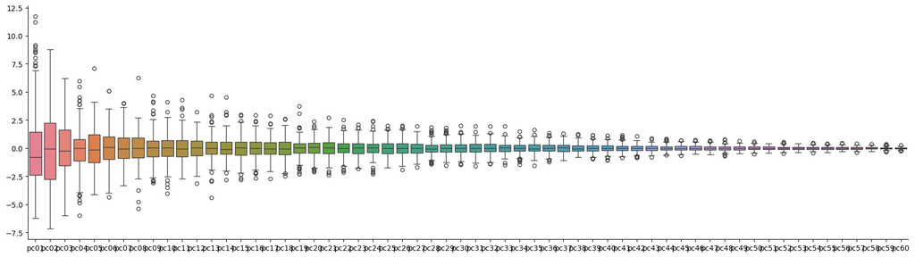

```python
sns.catplot(data=sonar_pca_df, kind="box", aspect=3.5)

plt.show()
```

Lets use the describe method to look at the values of the summary stats!

```python
sonar_pca_df.describe().round(3)
```

|  | pc01 | pc02 | pc03 | pc04 | pc05 | pc06 | pc07 | pc08 | pc09 | pc10 | ... | pc51 | pc52 | pc53 | pc54 | pc55 | pc56 | pc57 | pc58 | pc59 | pc60 |
| --- | --- | --- | --- | --- | --- | --- | --- | --- | --- | --- | --- | --- | --- | --- | --- | --- | --- | --- | --- | --- | --- |
| count | 208.000 | 208.000 | 208.000 | 208.000 | 208.000 | 208.000 | 208.000 | 208.000 | 208.000 | 208.000 | ... | 208.000 | 208.000 | 208.000 | 208.000 | 208.000 | 208.000 | 208.000 | 208.000 | 208.000 | 208.000 |
| mean | 0.000 | -0.000 | 0.000 | -0.000 | 0.000 | 0.000 | 0.000 | -0.000 | 0.000 | 0.000 | ... | -0.000 | -0.000 | -0.000 | 0.000 | -0.000 | 0.000 | -0.000 | -0.000 | -0.000 | -0.000 |
| std | 3.502 | 3.375 | 2.270 | 1.850 | 1.737 | 1.565 | 1.406 | 1.355 | 1.244 | 1.226 | ... | 0.171 | 0.169 | 0.152 | 0.149 | 0.139 | 0.128 | 0.122 | 0.108 | 0.106 | 0.081 |
| min | -6.221 | -7.168 | -5.974 | -5.976 | -4.127 | -4.364 | -3.312 | -5.386 | -3.103 | -4.013 | ... | -0.409 | -0.481 | -0.404 | -0.414 | -0.383 | -0.310 | -0.397 | -0.284 | -0.344 | -0.240 |
| 25% | -2.394 | -2.754 | -1.564 | -1.119 | -1.273 | -0.993 | -0.890 | -0.859 | -0.737 | -0.690 | ... | -0.118 | -0.103 | -0.110 | -0.084 | -0.107 | -0.090 | -0.085 | -0.078 | -0.058 | -0.046 |
| 50% | -0.806 | -0.047 | -0.255 | 0.001 | -0.146 | 0.064 | -0.068 | -0.030 | 0.034 | 0.031 | ... | 0.003 | 0.000 | 0.009 | 0.002 | 0.003 | 0.002 | 0.006 | -0.012 | 0.000 | 0.004 |
| 75% | 1.456 | 2.238 | 1.626 | 0.808 | 1.206 | 1.005 | 0.931 | 0.926 | 0.627 | 0.694 | ... | 0.119 | 0.104 | 0.105 | 0.089 | 0.079 | 0.080 | 0.081 | 0.072 | 0.056 | 0.053 |
| max | 11.727 | 8.774 | 6.224 | 5.984 | 7.101 | 5.103 | 4.023 | 6.281 | 4.673 | 4.129 | ... | 0.421 | 0.533 | 0.413 | 0.479 | 0.394 | 0.473 | 0.405 | 0.343 | 0.376 | 0.278 |

8 rows × 60 columns

Visualize the standard deviation!!!

```python
sonar_pca_df.describe().loc["std"]
```

```
pc01    3.502415
pc02    3.375367
pc03    2.270413
pc04    1.850399
pc05    1.737458
pc06    1.565497
pc07    1.406023
pc08    1.355253
pc09    1.243790
pc10    1.225513
pc11    1.118563
pc12    1.070844
pc13    1.026280
pc14    0.963094
pc15    0.927802
pc16    0.905826
pc17    0.862753
pc18    0.839390
pc19    0.788323
pc20    0.768270
pc21    0.754443
pc22    0.731511
pc23    0.711589
pc24    0.681716
pc25    0.659735
pc26    0.647951
pc27    0.609103
pc28    0.566128
pc29    0.562450
pc30    0.546511
pc31    0.535819
pc32    0.512801
pc33    0.473867
pc34    0.450554
pc35    0.432673
pc36    0.427526
pc37    0.416476
pc38    0.383997
pc39    0.363776
pc40    0.355919
pc41    0.333572
pc42    0.308869
pc43    0.287138
pc44    0.275326
pc45    0.248871
pc46    0.239218
pc47    0.237829
pc48    0.206556
pc49    0.189185
pc50    0.177284
pc51    0.171398
pc52    0.169086
pc53    0.152103
pc54    0.148690
pc55    0.139306
pc56    0.127642
pc57    0.121896
pc58    0.107941
pc59    0.106226
pc60    0.081477
Name: std, dtype: float64
```

Use Pandas plotting methods to show the std vs the PCA number.

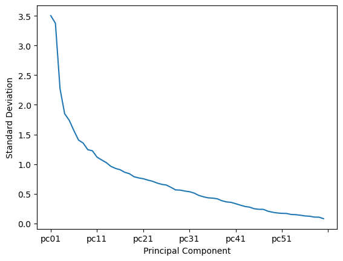

```python
fig, ax = plt.subplots()

sonar_pca_df.describe().loc["std"].plot(ax=ax)
ax.set_xlabel("Principal Component")
ax.set_ylabel("Standard Deviation")

plt.show()
```

High ordeded principle components have smaller variations.

This is by design!!

PCA creates the new vars such that PC01 has the HIGHEST variance.

Then, PCA created PC02 to have the NEXT highest variation.

Then, PCA created PC03 to have the NEXT hight variation.

So on and so on, the variation decreased for each subsequent PC!!!

The max number of PCs equals the number of cols in the data!!!

One more important aspect of the PCs!!

We previously saw that the original 60 numeric cols were correlated.

Lets check the correlation structure of the newly created PCs.

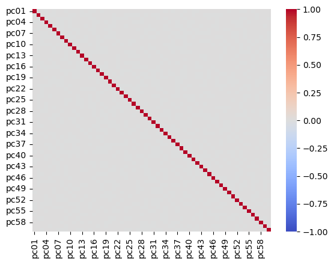

```python
fig, ax = plt.subplots()

sns.heatmap(data=sonar_pca_df.corr(),
            vmax=1, vmin=-1, center=0,
            cmap="coolwarm",
            ax=ax)

plt.show()
```

PCA is created such that the NEW vars are UNCORRELATED!!

PCA is created such that the LOW NUMBERED PCs have the HIGHEST VARIATION while the HIGHEST NUMBERED PCs have the LOWEST VARIATION!

BUT ALL PCS ARE UNCORRELATED!

## Why does this matter?

We have used the FIRST TWO PCs to help our visualizations.

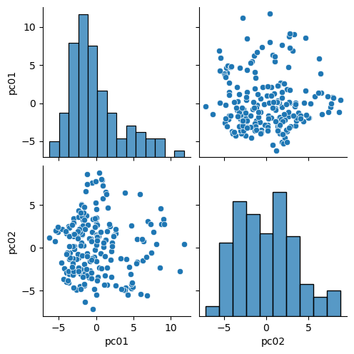

```python
sns.pairplot(data=sonar_pca_df.iloc[:, :2])
```

But we now know there are more PCs!!

We could consider explorting more PCs than just the first 2!!!

This is helpful when there are dozens if not hundreds of vars in teh data and those vars have some kind of correlation structure!

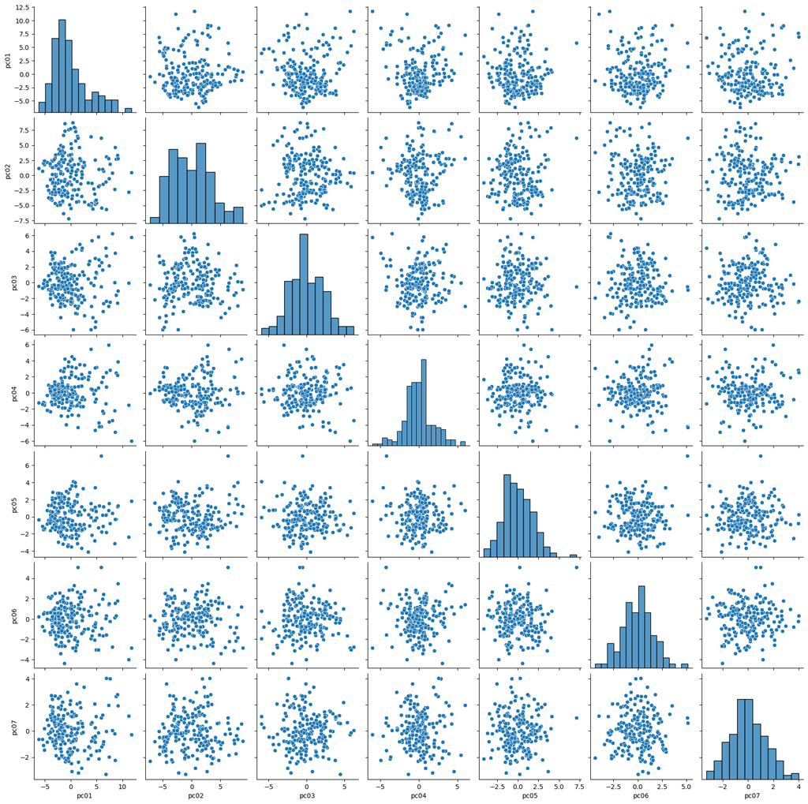

```python
sns.pairplot(data=sonar_pca_df.iloc[:, :7])
```

You can also group or condition PCs by categorical variables!!

```python
sonar_pca_df["X60"] = sonar_df.X60
```

```python
sonar_pca_df.dtypes
```

```
pc01    float64
pc02    float64
pc03    float64
pc04    float64
pc05    float64
         ...
pc57    float64
pc58    float64
pc59    float64
pc60    float64
X60      object
Length: 61, dtype: object
```

Lets first use pair plots to show the CONDITIONAL KDE and the CONDITIONAL SCATTERPLOT between the PAIRS of PCs GIVEN X60.

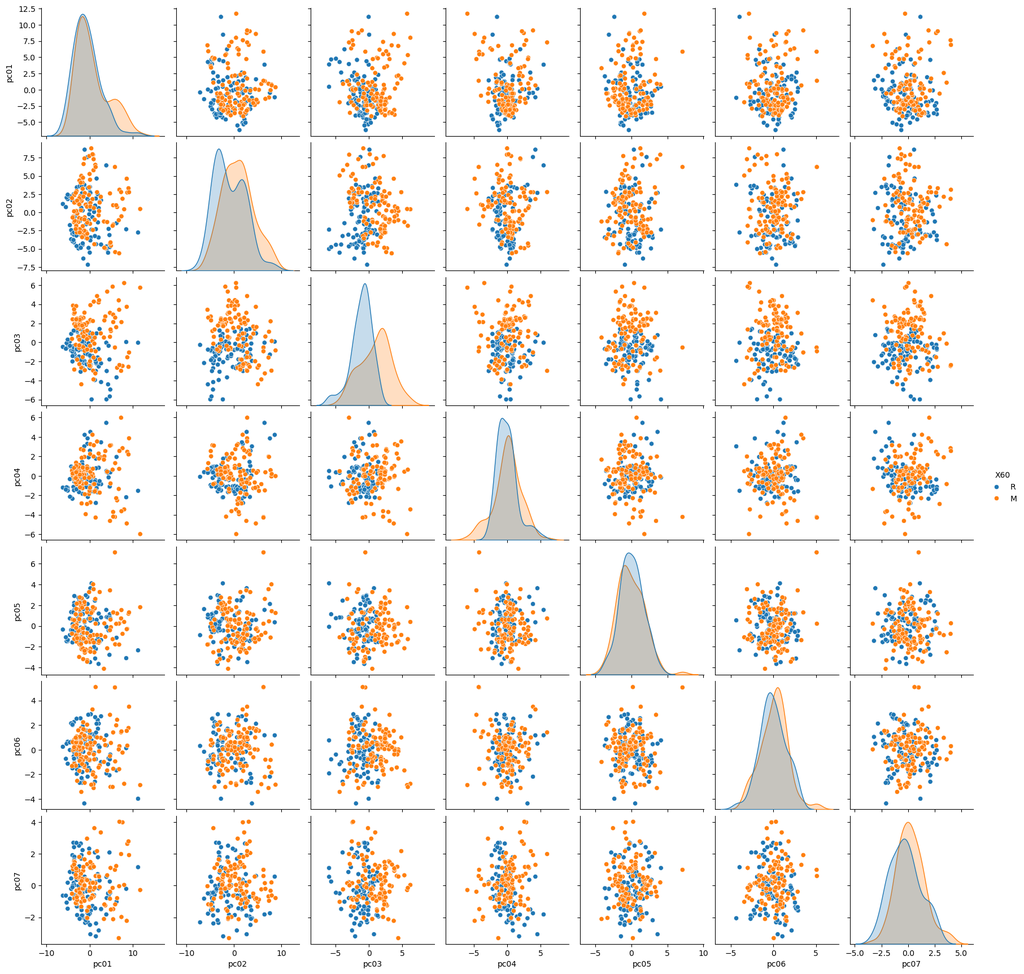

```python
sns.pairplot(data=sonar_pca_df,
             vars=["pc%02d" % d for d in range(1, 7+1)],
             hue="X60",
            diag_kws={"common_norm": False})
```